# IBM Capstone Project: Battle of the Neighborhoods

## Chicago Neighborhood Opportunity Fund Allocation

See the main part of this project in Capstone_BattleOfNeighborhoods.ipynb.

Here we do a lot of what is done in the main report notebook. I used this notebook to do a lot of messy work, exporing data and sometimes going down dead ends. This is only here to clarifiy the path not taken.

## Setup

```python
import pyreadr
import re
import os
import platform
import numpy as np
import pandas as pd
import matplotlib.pyplot as plt
from matplotlib import colors
import matplotlib.patheffects as PathEffects
from sklearn.cluster import AgglomerativeClustering
import json
import folium
from folium import plugins
from folium.plugins import FloatImage
import time
import imageio

from PIL import Image

import webbrowser
from selenium import webdriver
import fileinput
import math
```

```python
from IPython.core.display import HTML
HTML("""
<style>
.output_png {
    display: table-cell;
    text-align: center;
    vertical-align: middle;
}
</style>
""")
```

```python
homepath=os.getcwd()

datadir = os.path.join('.', 'data')
if not os.path.exists(datadir):
    os.makedirs(datadir)
ltdbdir = os.path.join(datadir, 'ltdb')
if not os.path.exists(ltdbdir):
    os.makedirs(ltdbdir)
htmldir = os.path.join(datadir, 'maphtml')
if not os.path.exists(htmldir):
    os.makedirs(htmldir)
differenceMatrix_rds = os.path.join(ltdbdir, 'differenceMatrix.RDS')
ltdb_series_rds=os.path.join(ltdbdir, "ltdb_series.RDS")
ltdb_seq_cluster_rds=os.path.join(ltdbdir, "ltdb_seq_cluster.RDS")
colorcode_csv=os.path.join(ltdbdir, 'colorcode.csv')

chicago_southwestinvest_nof_csv=os.path.join(datadir, 'chicago_southwestinvest_nof.csv')
isw_rfp_tract_csv=os.path.join(datadir, 'isw_rfp_tract.csv')
isw_rfp_tract_geojson=os.path.join(datadir, 'isw_rfp_tract.geojson')

cook_tract_geojson_file = os.path.join(datadir, 'cook_tract.geojson')
chicago_only_neighborhood_geojson=os.path.join(datadir, 'chicago_only_neighborhood.geojson')

if platform.system() == 'Windows':
    chromedriver=r'C:\DRIVERS\chromedriver\chromedriver.exe'
    if (not os.path.isfile(chromedriver)):
        sys.exit("ERROR: Provide a path to a chrome drive on this system")
else:
    sys.exit("ERROR: Provide a path to a chrome drive on this system")
```

## Exploritory

### Import R data

```python
differenceMatrix=pyreadr.read_r(differenceMatrix_rds)
diffMatrix=np.asmatrix(differenceMatrix[None])
clustering = AgglomerativeClustering(n_clusters=10, linkage="ward").fit(diffMatrix)
```

### Run all supported scikit-learn hiearch clusters for our data

```python
clustering2 = AgglomerativeClustering(n_clusters=10, affinity= "precomputed", linkage="average").fit(diffMatrix)
clustering3 = AgglomerativeClustering(n_clusters=10, affinity= "precomputed", linkage="complete").fit(diffMatrix)
clustering4 = AgglomerativeClustering(n_clusters=10, affinity= "precomputed", linkage="single").fit(diffMatrix)
```

Preview: Because some analysis below we know only the linkage="complete" and linkage="ward" are worth saving so that is why we are adding only those to the ltdb_seq_cluster dataframe

```python
# differenceMatrix.RDS and ltdb_seq_cluster.RDS were derived from the same
# sequence file with census tracts as the data points. Therefore, the clustering
# labels created above will be in the same order and the file we are importing
ltdb_seq_cluster_rds
ltdb_seq_cluster_dict=pyreadr.read_r(ltdb_seq_cluster_rds)
ltdb_seq_cluster=pd.DataFrame(ltdb_seq_cluster_dict[None])
ltdb_seq_cluster['Pseqclust']=clustering.labels_
ltdb_seq_cluster['PMseqclust']=clustering3.labels_
```

```python
# These are the codes created by the K-means clustering in QualifiedInvestmentArea.ipynb. 5 codes in all
colorcode=pd.read_csv(colorcode_csv)
colorlist = [colorcode[colorcode['numcode']==0]['color'].values[0],colorcode[colorcode['numcode']==1]['color'].values[0],
             colorcode[colorcode['numcode']==2]['color'].values[0],colorcode[colorcode['numcode']==3]['color'].values[0],
             colorcode[colorcode['numcode']==4]['color'].values[0]]
labels = [colorcode[colorcode['numcode']==0]['labels'].values[0],colorcode[colorcode['numcode']==1]['labels'].values[0],
          colorcode[colorcode['numcode']==2]['labels'].values[0],colorcode[colorcode['numcode']==3]['labels'].values[0],
          colorcode[colorcode['numcode']==4]['labels'].values[0]]
```

```python
def large_legend():
    data = [.4, .4, .4, .4, .4]
    fig, ax = plt.subplots(figsize=(3, 3))
    ax.barh(range(len(data)), data, color=colorlist)
    for i, v in enumerate(labels):
        ax.text(.1, i - .1, str(labels[i]), color='white', fontweight='bold', size=12,
                path_effects=[PathEffects.Stroke(linewidth=1, foreground='black'),PathEffects.Normal()])
    plt.ylabel(labels)
    plt.gca().set_axis_off()
    plt.show()
```

```python
# This file was used to create differenceMatrix.RDS, therefore order of the census tracts
#  will match the order of the labels assigned in the AgglomerativeClustering call
ltdb_series_dict=pyreadr.read_r(ltdb_series_rds)
ltdb_series=pd.DataFrame(ltdb_series_dict[None])
convert_dict = {'1970': int, '1980': int, '1990': int, '2000': int, '2010':int, '2019': int}
ltdb_series = ltdb_series.astype(convert_dict)
```

### Looking at all sequences for ward's method cluster

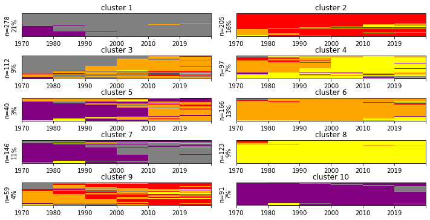

```python
def seqIplot(axn, df, chartnum):
    rows = len(df)
    cols = 6
    Z = df.iloc[:,1:len(df.columns)]
    x = np.arange(7)
    y = np.arange(len(df) + 1)
    cmap = colors.ListedColormap(colorlist)
    axn.pcolormesh(x, y, Z, shading='flat', vmin=0, vmax=4, cmap=cmap)
    axn.set_xticklabels(df.columns[1:7])
    axn.set_yticklabels([])
    axn.tick_params(axis=u'y', which=u'both',length=0)
    axn.set(ylabel="n=" + str(len(df)) + '\n' + str(round((len(df) / len(ltdb_series)) * 100)) + '%'  )
    axn.set_title('cluster ' + str(chartnum))

##########
fig, ax = plt.subplots(5,2, figsize=(10, 5))
fig.tight_layout()
for row_n, ax_row in enumerate(ax):
    for col_n, ax_cell in enumerate(ax_row):
        chartn=row_n * len(ax_row) + (col_n + 1)
        tempdf=ltdb_series[clustering.labels_==(chartn - 1)]
        tempdf=tempdf.sort_values(by=['1970', '1980', '1990', '2000', '2010', '2019'])
        seqIplot(ax_cell, tempdf, chartn)

plt.show()
large_legend()
```

```python
struggling_clusters=[]
def seqrplot(axn, df, chartnum):
    seqcount=pd.DataFrame(df.groupby(df.columns[1:7].tolist(),as_index=False).size())
    seqcount.reset_index(inplace=True)
    seqcount=seqcount.rename({0:'reccount'}, axis=1)
    Z=np.array([])
    while (Z.shape[0] / len(df)) < 0.25:
        mostfreq=seqcount.reccount.idxmax()
        mostfreqcount=seqcount.reccount.max()
        if Z.shape[0]==0:
            Z=np.repeat(np.array(seqcount.loc[[mostfreq], ['1970', '1980', '1990', '2000', '2010', '2019']]), mostfreqcount, axis=0)
        else:
            Z=np.concatenate((Z, np.repeat(np.array(seqcount.loc[[mostfreq], ['1970', '1980', '1990', '2000', '2010', '2019']]), mostfreqcount, axis=0)))
        seqcount.drop(mostfreq, inplace=True)
    if sum(Z[:,-1]==colorcode.loc[colorcode['labels']=='Struggling', 'numcode'].values[0]) / Z.shape[0] >= 0.5:
        struggling_clusters.append(chartnum - 1)

    rows = Z.shape[0]
    cols = 6
    x = np.arange(7)
    y = np.arange(rows + 1)
    cmap = colors.ListedColormap(colorlist)
    axn.pcolormesh(x, y, Z, shading='flat', vmin=0, vmax=4, cmap=cmap)
    axn.set_xticklabels(df.columns[1:7])
    axn.set_yticklabels([])
    axn.tick_params(axis=u'y', which=u'both',length=0)
    axn.set(ylabel="n=" + str(Z.shape[0]))
    axn.set_title('Most Frequent Patterns: Cluster ' + str(chartnum) + ', Density Coverage=' + str(round((Z.shape[0] / len(df))*100,ndigits=1)) + '%')
```

### Look at dominate sequences for all clusters

This clustering was made using a distance matrix and ward linkage to cluster by minimizing variance, which is not supported by the scikit-learn library

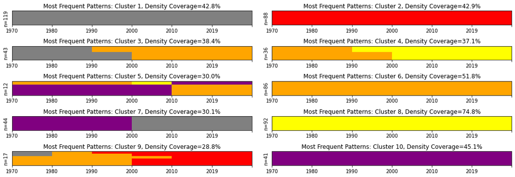

```python
##########
fig, ax = plt.subplots(5,2, figsize=(15, 5))
fig.tight_layout()
fig.subplots_adjust(hspace=1.5)
for row_n, ax_row in enumerate(ax):
    for col_n, ax_cell in enumerate(ax_row):
        chartn=row_n * len(ax_row) + (col_n + 1)
        tempdf=ltdb_series[clustering.labels_==(chartn - 1)]
        tempdf=tempdf.sort_values(by=['1970', '1980', '1990', '2000', '2010', '2019'])
        seqrplot(ax_cell, tempdf, chartn)

plt.show()
large_legend()
```

This clustering was made using a distance matrix and linkage to cluster by minimizing the average of the distances of each observation. Observed results were not good

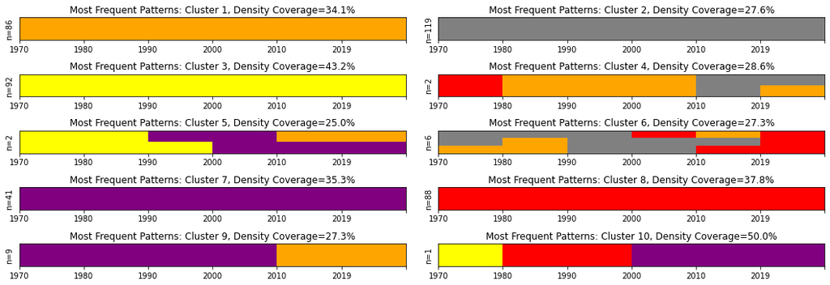

```python
struggling_clusters=[]

##########
fig, ax = plt.subplots(5,2, figsize=(15, 5))
fig.tight_layout()
fig.subplots_adjust(hspace=1.5)
for row_n, ax_row in enumerate(ax):
    for col_n, ax_cell in enumerate(ax_row):
        chartn=row_n * len(ax_row) + (col_n + 1)
        tempdf=ltdb_series[clustering2.labels_==(chartn - 1)]
        tempdf=tempdf.sort_values(by=['1970', '1980', '1990', '2000', '2010', '2019'])
        seqrplot(ax_cell, tempdf, chartn)

plt.show()
large_legend()
```

This clustering was made using a distance matrix and linkage to cluster by minimizing the maximum distances between all observations. Observed results were similiar to results obtained in R.

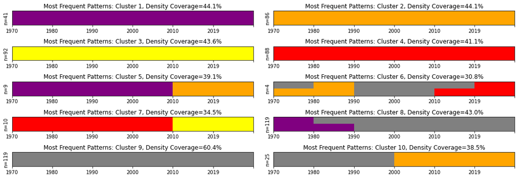

```python
struggling_clusters=[]

##########
fig, ax = plt.subplots(5,2, figsize=(15, 5))
fig.tight_layout()
fig.subplots_adjust(hspace=1.5)
for row_n, ax_row in enumerate(ax):
    for col_n, ax_cell in enumerate(ax_row):
        chartn=row_n * len(ax_row) + (col_n + 1)
        tempdf=ltdb_series[clustering3.labels_==(chartn - 1)]
        tempdf=tempdf.sort_values(by=['1970', '1980', '1990', '2000', '2010', '2019'])
        seqrplot(ax_cell, tempdf, chartn)

plt.show()
large_legend()
```

This clustering was made using a distance matrix and linkage to cluster by minimizing the minimum of the distances between all observations. Observed results obviously inappropriate for this exercise.

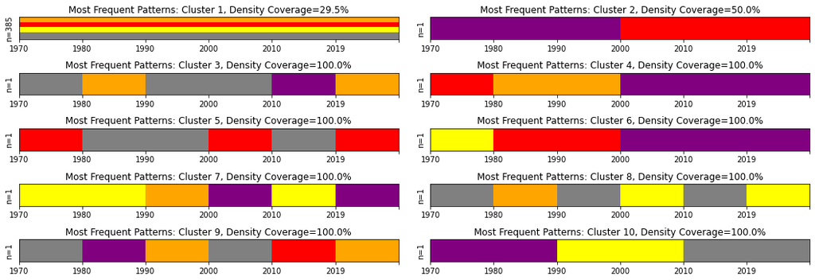

```python
struggling_clusters=[]

##########
fig, ax = plt.subplots(5,2, figsize=(15, 5))
fig.tight_layout()
fig.subplots_adjust(hspace=1.5)
for row_n, ax_row in enumerate(ax):
    for col_n, ax_cell in enumerate(ax_row):
        chartn=row_n * len(ax_row) + (col_n + 1)
        tempdf=ltdb_series[clustering4.labels_==(chartn - 1)]
        tempdf=tempdf.sort_values(by=['1970', '1980', '1990', '2000', '2010', '2019'])
        seqrplot(ax_cell, tempdf, chartn)

plt.show()
large_legend()
```

### Looking at the results, not all looks good

Using average distance doesn't look good

| 2010 Study | Transition Pattern | R Cluster | Python dif | Python avg | Python max |
| --- | --- | --- | --- | --- | --- |
| 1 | Struggling to any other | 7 | NA | NA | 7 |
| 2 | Blue Collar to Young Urban | 6 | 4 | NA | NA |
| 3 | Stable Young Urban | 3 | 8 | 3 | 3 |
| 4 | Stable Older Suburban | 4 | 1 | 2 | 9 |
| 5 | Older Suburban to Blue Collar | 5 | 3 | NA | 10 |
| 6 | Stable Struggling | 1 | 2 | 8 | 4 |
| 7 | Stable Blue Collar | 10 | 6 | 1 | 2 |
| 8 | Blue Collar to Struggling | NA | 9 | NA | 6 |
| 9 | New Suburban to Old Suburban | 8 | 7 | NA | 8 |
| 10 | New Suburban | 9 | 10 | 7 | 1 |
| NA | Alternate Blue Collar, Young Urban | 2 | NA | NA | NA |
| NA | Alternate Blue Collar, New Suburban | NA | 5 | NA | NA |
| NA | Struggling to BC & OS | NA | NA | 4 | NA |
| NA | Young Urban to BC & NS | NA | NA | 5 | NA |
| NA | Blue Collar & Old Sub to Struggling | NA | NA | 6 | NA |
| NA | New Suburban to Blue Collar | NA | NA | 9 | 5 |
| NA | Young Urban to Struggle to N.S | NA | NA | 10 | NA |

```python
isw_rfp_tract=pd.read_csv(isw_rfp_tract_csv, dtype={'CensusTract': object})
```

```python
cluster_type=pd.DataFrame({'ClustDescript':["Struggling to any other","Blue Collar to Young Urban","Stable Young Urban",
                                            "Stable Older Suburban","Older Suburban to Blue Collar","Stable Struggling",
                                            "Stable Blue Collar","Blue Collar to Struggling","New Suburban to Old Suburban",
                                            "New Suburban","Alternate Blue Collar, Young Urban","Alternate Blue Collar, New Suburban",
                                            "New Suburban to Blue Collar"],
                           'Onum': [1,2,3,4,5,6,7,8,9,10,None,None,None],
                           'Rnum': [7,6,3,4,5,1,10,None,8,9,2,None,None],
                           'Pnum': [None,4,8,1,3,2,6,9,7,10,None,5,None],
                           'PMnum': [7,None,3,9,10,4,2,6,8,1,None,None,5],
                           'Ocnt': [61,65,148,290,102,135,164,59,134,158,None,None,None]})
cluster_type['Rcnt']=[len(ltdb_seq_cluster[ltdb_seq_cluster['Rseqclust']==i]) for i in cluster_type['Rnum']]
cluster_type['Pcnt']=[len(ltdb_seq_cluster[ltdb_seq_cluster['Pseqclust']==i]) for i in cluster_type['Pnum']]
cluster_type['PMcnt']=[len(ltdb_seq_cluster[ltdb_seq_cluster['PMseqclust']==i]) for i in cluster_type['PMnum']]
#cluster_type['R_Ward_dif']=abs(cluster_type['Rcnt'] - cluster_type['Pcnt'])
#cluster_type['R_Max_dif']=abs(cluster_type['Rcnt'] - cluster_type['PMcnt'])
```

### Using Jaccard to compare R with Ward and Max distance

```python
# copied from https://stackoverflow.com/questions/56217197/how-to-calculate-jaccard-similarity-distance-between-two-list-of-strings
def jaccard_similarity(list1, list2):
    intersection = len(set(list1).intersection(list2)) #no need to call list here
    union = len(list1 + list2) - intersection #you only need to call len once here
    return intersection / union #also no need to cast to float as this will be done for you
```

```python
jaccard_r_p=[]
jaccard_r_pm=[]
rlist_all=[]
plist_all=[]
pmlist_all=[]
for r,p,pm, descript in zip(cluster_type['Rnum'],cluster_type['Pnum'],cluster_type['PMnum'], cluster_type['ClustDescript']):
    rlist=list(ltdb_seq_cluster[ltdb_seq_cluster['Rseqclust']==r]['CensusTract'])
    plist=list(ltdb_seq_cluster[ltdb_seq_cluster['Pseqclust']==p-1]['CensusTract'])
    pmlist=list(ltdb_seq_cluster[ltdb_seq_cluster['PMseqclust']==pm-1]['CensusTract'])
    rlist_all.extend(list(ltdb_seq_cluster[ltdb_seq_cluster['Rseqclust']==r]['CensusTract'] + descript))
    plist_all.extend(list(ltdb_seq_cluster[ltdb_seq_cluster['Pseqclust']==p-1]['CensusTract'] + descript))
    pmlist_all.extend(list(ltdb_seq_cluster[ltdb_seq_cluster['PMseqclust']==pm-1]['CensusTract'] + descript))
    if not math.isnan(r) and not math.isnan(p):
        jaccard_r_p.append(round(jaccard_similarity(rlist, plist),3))
    else:
        jaccard_r_p.append(None)
    if not math.isnan(r) and not math.isnan(pm):
        jaccard_r_pm.append(round(jaccard_similarity(rlist, pmlist),3))
    else:
        jaccard_r_pm.append(None)
cluster_type['J_Ward']=pd.Series(jaccard_r_p)
cluster_type['J_Max']=pd.Series(jaccard_r_pm)
```

```python
jaccard_similarity(rlist_all, plist_all)
jaccard_similarity(rlist_all, pmlist_all)
```

```
0.6339950372208437
```

## Put it together with the RFP data

```python
isw_rfp_tract=pd.read_csv(isw_rfp_tract_csv, dtype={'CensusTract': object})
l=list(set(isw_rfp_tract.CensusTract))
dftemp=ltdb_seq_cluster[ltdb_seq_cluster.CensusTract.isin(l)]
dftemp.reset_index(drop=True, inplace=True)
dftemp['R Clustering']=[cluster_type[cluster_type['Rnum']==x]['ClustDescript'].values[0] for x in list(dftemp.Rseqclust)]
dftemp['Python with Ward']=[cluster_type[cluster_type['Pnum']==x+1]['ClustDescript'].values[0] for x in list(dftemp.Pseqclust)]
dftemp['Python by Max<br>Distance']=[cluster_type[cluster_type['PMnum']==x+1]['ClustDescript'].values[0] for x in list(dftemp.PMseqclust)]
dftemp.drop(['Rseqclust', 'Pseqclust', 'PMseqclust'], axis=1, inplace=True)
dftemp=dftemp.rename(columns={'CensusTract': 'Census Tract<br>with RFP'})
html1=dftemp.style.hide_index().set_precision(0).render()
tstyle=r'<table style="margin-left:auto;margin-right:auto;"'
html2=re.sub('<style .*\n</style>', '', html1, 1)               # Erase the separate style section
html3=re.sub('<table id=\"[^\"]*\"', tstyle, html2,1)           # Replace the id with the explict style statements
HTML(html3)
```

| Census Tract with RFP | R Clustering | Python with Ward | Python by Max Distance |
| --- | --- | --- | --- |
| 17031230500 | Stable Blue Collar | Stable Blue Collar | Stable Blue Collar |
| 17031231500 | Stable Struggling | Stable Struggling | Stable Struggling |
| 17031251200 | Stable Blue Collar | Stable Blue Collar | Stable Blue Collar |
| 17031292200 | Stable Struggling | Stable Struggling | Stable Struggling |
| 17031381200 | Stable Struggling | Stable Struggling | Stable Struggling |
| 17031381800 | Stable Struggling | Stable Struggling | Stable Struggling |
| 17031431301 | Stable Struggling | Stable Struggling | Stable Struggling |
| 17031460100 | Stable Struggling | Stable Struggling | Stable Struggling |
| 17031460700 | Stable Struggling | Stable Struggling | Stable Struggling |
| 17031611200 | Alternate Blue Collar, Young Urban | Blue Collar to Struggling | Stable Blue Collar |
| 17031710800 | Stable Blue Collar | Blue Collar to Struggling | Stable Blue Collar |
| 17031834800 | Stable Struggling | Stable Struggling | Stable Struggling |
| 17031843000 | Stable Struggling | Stable Struggling | Stable Struggling |

### Explore the data with some crude metrics

```python
df=cluster_type.copy()
#df.columns=['Description', 'Original<br>Cluster', "R<br>Cluster", "Python<br>Ward<br>Cluster", "Python<br>Max<br>Cluster",
#                           "Original<br>count", "R<br>count", "Python<br>Ward<br>count", "Python<br>Max<br>count", "Ward<br>diff", "Max<br>diff","J Ward", "J Max"]
df.columns=['Description', 'Original<br>Cluster', "R<br>Cluster", "Python<br>Ward<br>Cluster", "Python<br>Max<br>Cluster",
                           "Original<br>count", "R<br>count", "Python<br>Ward<br>count", "Python<br>Max<br>count", "J Ward", "J Max"]
html1=df.style.hide_index().set_precision(0).format({'J Ward': "{:.3f}", 'J Max': '{:.3f}'}).render()
#df.style.format("{:.2%}")
#df.style.format({'B': "{:0<4.0f}", 'D': '{:+.2f}'})
tstyle=r'<table style="margin-left:auto;margin-right:auto;"'
html2=re.sub('<style .*\n</style>', '', html1, 1)               # Erase the separate style section
html3=re.sub('<table id=\"[^\"]*\"', tstyle, html2,1)           # Replace the id with the explict style statements
HTML(html3)
```

| Description | Original Cluster | R Cluster | Python Ward Cluster | Python Max Cluster | Original count | R count | Python Ward count | Python Max count | J Ward | J Max |
| --- | --- | --- | --- | --- | --- | --- | --- | --- | --- | --- |
| Struggling to any other | 1 | 7 | nan | 7 | 61 | 23 | 0 | 277 | nan | 0.677 |
| Blue Collar to Young Urban | 2 | 6 | 4 | nan | 65 | 77 | 40 | 0 | 0.596 | nan |
| Stable Young Urban | 3 | 3 | 8 | 3 | 148 | 142 | 59 | 214 | 0.866 | 0.673 |
| Stable Older Suburban | 4 | 4 | 1 | 9 | 290 | 175 | 205 | 65 | 0.515 | 0.860 |
| Older Suburban to Blue Collar | 5 | 5 | 3 | 10 | 102 | 97 | 97 | 0 | 0.608 | 0.604 |
| Stable Struggling | 6 | 1 | 2 | 4 | 135 | 204 | 112 | 23 | 0.802 | 0.953 |
| Stable Blue Collar | 7 | 10 | 6 | 2 | 164 | 150 | 146 | 211 | 0.806 | 0.751 |
| Blue Collar to Struggling | 8 | nan | 9 | 6 | 59 | 0 | 91 | 29 | nan | nan |
| New Suburban to Old Suburban | 9 | 8 | 7 | 8 | 134 | 209 | 123 | 197 | 0.286 | 0.664 |
| New Suburban | 10 | 9 | 10 | 1 | 158 | 183 | 0 | 195 | 0.481 | 0.408 |
| Alternate Blue Collar, Young Urban | nan | 2 | nan | nan | nan | 57 | 0 | 0 | nan | nan |
| Alternate Blue Collar, New Suburban | nan | nan | 5 | nan | nan | 0 | 166 | 0 | nan | nan |
| New Suburban to Blue Collar | nan | nan | nan | 5 | nan | 0 | 0 | 13 | nan | nan |

```python
print("R Ward similarity=" + str(jaccard_similarity(rlist_all, plist_all)) + "\n" + "R Max similarity=" + str(jaccard_similarity(rlist_all, pmlist_all)))
```

```
R Ward similarity=0.5296167247386759
R Max similarity=0.6339950372208437
```

## Finally, visualize it

```python
colordict={'Stable Struggling': 'cyan', 'Stable Blue Collar': 'violet', 'Blue Collar to Struggling': 'orange', 'Alternate Blue Collar, Young Urban': 'orange'}
def overlay_map_legend(seqclust, clusterlist):
    plt.ioff()
    if seqclust=='Pseqclust':
        labels=[cluster_type[cluster_type['Pnum']==x+1]['ClustDescript'].values[0] for x in clusterlist]
    elif seqclust=='PMseqclust':
        labels=[cluster_type[cluster_type['PMnum']==x+1]['ClustDescript'].values[0] for x in clusterlist]
    else:
        labels=[cluster_type[cluster_type['Rnum']==x]['ClustDescript'].values[0] for x in clusterlist]

    maxletters=len(max(labels, key=len))
    colorlist=[colordict[x] for x in labels]
    bars = [.3] * len(clusterlist)
    fig, ax = plt.subplots(figsize=(maxletters/6.6, len(clusterlist) - len(clusterlist)/3 ))  # trial and error sizing
    ax.barh(range(len(bars)), bars, color=colorlist)
    for i, v in enumerate(labels):
        ax.text(.01, i - .1, str(labels[i]), color='white', fontweight='bold', size=13,
                path_effects=[PathEffects.Stroke(linewidth=1, foreground='black'),PathEffects.Normal()])
    plt.ylabel(labels)
    plt.gca().set_axis_off()

    fig1 = plt.gcf()
    #maplegend=os.path.join(htmldir, 'maplegend.png')
    fig1.savefig('maplegend.png')
    #plt.show()
    plt.close()
```

```python
#with open(chicago_only_neighborhood_geojson) as f:
#    chicago_only_neighborhood = json.load(f)
#chicago_southwestinvest_nof=pd.read_csv(chicago_southwestinvest_nof_csv)
#isw_list=list(chicago_southwestinvest_nof.neighborhood)
homepath=os.getcwd()

def map_hiearch_cluster(seqclust, clusterlist, altdescript=""):
    with open(cook_tract_geojson_file) as json_file:
        cook_tract_geojson = json.load(json_file)   # This creates a dictionary object of the whole json file
    for i in range(len(cook_tract_geojson['features'])):
        if cook_tract_geojson['features'][i]['properties']['CensusTract'] in ['17031980100', '17031990000']:
            cook_tract_geojson['features'][i]['properties']['cluster'] = 11
        else:
            if len(ltdb_seq_cluster[ltdb_seq_cluster['CensusTract'] == cook_tract_geojson['features'][i]['properties']['CensusTract']])==1:
                cook_tract_geojson['features'][i]['properties']['cluster'] = int(ltdb_seq_cluster[ltdb_seq_cluster['CensusTract'] == cook_tract_geojson['features'][i]['properties']['CensusTract']][seqclust])
                #print(cook_tract_geojson['features'][i]['properties']['cluster'])  # debug
                if seqclust=='Pseqclust':
                    cook_tract_geojson['features'][i]['properties']['ClustDescript']=cluster_type[cluster_type['Pnum']==cook_tract_geojson['features'][i]['properties']['cluster']+1]['ClustDescript'].values[0]
                elif seqclust=='PMseqclust':
                    cook_tract_geojson['features'][i]['properties']['ClustDescript']=cluster_type[cluster_type['PMnum']==cook_tract_geojson['features'][i]['properties']['cluster']+1]['ClustDescript'].values[0]
                else:
                    cook_tract_geojson['features'][i]['properties']['ClustDescript']=cluster_type[cluster_type['Rnum']==cook_tract_geojson['features'][i]['properties']['cluster']]['ClustDescript'].values[0]
            else:
                print(cook_tract_geojson['features'][i]['properties']['CensusTract'],
                      len(ltdb_seq_cluster[ltdb_seq_cluster['CensusTract'] == cook_tract_geojson['features'][i]['properties']['CensusTract']]))

    #ChiMap = folium.Map([41.7500,-87.6800], zoom_start=11, control_scale = True)
    ChiMap = folium.Map([41.700,-87.5000], zoom_start=11, control_scale = True)

    descript=''
    if seqclust=='Pseqclust':
        proglang='Python Ward to minimizes variance'
        #for i in range(len(clusterlist)):
        #    descript=descript + "<br>Cluster " + str(clusterlist[i] + 1) + '-' + cluster_type.loc[(cluster_type['Pnum'] - 1)==clusterlist[i], 'ClustDescript'].values[0]
    elif seqclust=='PMseqclust':
        proglang='Python: minimize maximum distances'
        #for i in range(len(clusterlist)):
        #    descript=descript + "<br>Cluster " + str(clusterlist[i] + 1) + '-' + cluster_type.loc[(cluster_type['PMnum'] - 1)==clusterlist[i], 'ClustDescript'].values[0]
    else:
        proglang='R Ward to minimize variance'
        #for i in range(len(clusterlist)):
        #    descript=descript + "<br>Cluster " + str(clusterlist[i]) + '-' + cluster_type.loc[cluster_type['Rnum']==clusterlist[i], 'ClustDescript'].values[0]
    if altdescript!="":
        descript=altdescript

    title_str=proglang + descript
    title_html = '''
                 <h3 align="left" style="font-size:16px ; margin-left:10px"><b>{}</b></h3>
                 '''.format(title_str)
    ChiMap.get_root().html.add_child(folium.Element(title_html))

    fgp = folium.FeatureGroup(name="Neighborhood")
    fill_tract = (lambda x: {'stroke': False,
                             'fill': True if x['properties']['cluster'] in clusterlist else False,
                             #'fill': True,
                             #'fill': False if x['properties']['CensusTract'] in ['17031980100', '17031990000'] else True,
                             'fillOpacity': 0.7,
                             'fillColor': colordict[x['properties']['ClustDescript']] if x['properties']['cluster'] in clusterlist else '#00000000'})
    polygons=folium.GeoJson(data=cook_tract_geojson,style_function=fill_tract,
                            tooltip=folium.features.GeoJsonTooltip(fields=['CensusTract', 'cluster'],aliases=['','']))
    fgp.add_child(polygons)
    ChiMap.add_child(fgp)

    #fgi = folium.FeatureGroup(name="Invest")
    #outlineinvestmentzone = (lambda x: {'stroke': True if x['properties']['pri_neigh'] in isw_list else False,
    #                                    'color': 'black', 'weight': 3, 'fill': False})
    #investpoly=folium.GeoJson(data=chicago_only_neighborhood,style_function=outlineinvestmentzone,
    #                        tooltip=folium.features.GeoJsonTooltip(fields=['pri_neigh'],aliases=['Hood:']))
    #fgi.add_child(investpoly)
    #ChiMap.add_child(fgi)

    for lat, lng, label, status in zip(isw_rfp_tract.lat, isw_rfp_tract.lng, isw_rfp_tract.Address, isw_rfp_tract.Status):
        folium.CircleMarker(
            [lat, lng],
            weight=1,
            radius=4,
            #color='red' if status=='Soliciting' else 'yellow' if status=='Reviewing' else 'green',
            color='black',
            popup=label,
            fill = True,
            fill_color='red' if status=='Soliciting' else 'yellow' if status=='Reviewing' else 'green',
            fill_opacity=0.9
        ).add_to(ChiMap)

    #html=seqclust + str(clusterlist[0]) + ".html"
    #png=seqclust + str(clusterlist[0]) + ".png"
    html=seqclust + ".html"
    png=seqclust + ".png"
    mapsave_html = os.path.join(htmldir, html)
    mapsave_png = os.path.join(htmldir, png)
    ChiMap.save(mapsave_html)
    # Turn ZoomControl off in each html file
    with fileinput.FileInput(mapsave_html, inplace=True) as file:
        for line in file:
            print(line.replace('zoomControl: true', 'zoomControl: false'), end='')

    # Convert html files to png (screenshot each html page)
    # We use a delay because we dont want to take a screenshot of the browser before the map is loaded
    os.chdir(htmldir)
    delay=5
    tmpurl='file://{path}/{mapfile}'.format(path=os.getcwd(),mapfile=html)

    browser=webdriver.Chrome(executable_path=chromedriver)
    browser.get(tmpurl)

    #Give the map tiles some time to load
    time.sleep(delay)
    browser.save_screenshot(png)
    browser.quit()
    image = Image.open(png)
    width, height =  image.size
    # Right, Upper, Left, Lower
    new_width=width - width/2
    new_height=height - height/2.5
    box = (0, 0, new_width, new_height)
    cropped_image = image.crop(box)
    cropped_image.save(png)

    mapimage=Image.open(png)
    width_map,height_map=mapimage.size
    plt.ioff()
    overlay_map_legend(seqclust, clusterlist)
    #maplegend_png=os.path.join(htmldir, 'maplegend.png')
    maplegend=Image.open('maplegend.png')
    maplegend_resz=maplegend.resize((int(width_map/2),int(height_map/4)))
    mapimage.paste(maplegend_resz,(0,height_map - int(height_map/4)),maplegend_resz)
    mapimage.save(png)

    os.chdir(homepath)
    plt.ion

l=list(set(isw_rfp_tract.CensusTract))
map_hiearch_cluster(seqclust='Pseqclust', clusterlist=list(set(ltdb_seq_cluster[ltdb_seq_cluster.CensusTract.isin(l)]['Pseqclust'])))
map_hiearch_cluster(seqclust='PMseqclust', clusterlist=list(set(ltdb_seq_cluster[ltdb_seq_cluster.CensusTract.isin(l)]['PMseqclust'])))
map_hiearch_cluster(seqclust='Rseqclust', clusterlist=list(set(ltdb_seq_cluster[ltdb_seq_cluster.CensusTract.isin(l)]['Rseqclust'])))
#for i in range(10):
#    map_hiearch_cluster(seqclust='Pseqclust', clusterlist=[i])
#for i in range(10):
#    map_hiearch_cluster(seqclust='PMseqclust', clusterlist=[i])
#for i in range(1,11):
#    map_hiearch_cluster(seqclust='Rseqclust', clusterlist=[i])
```

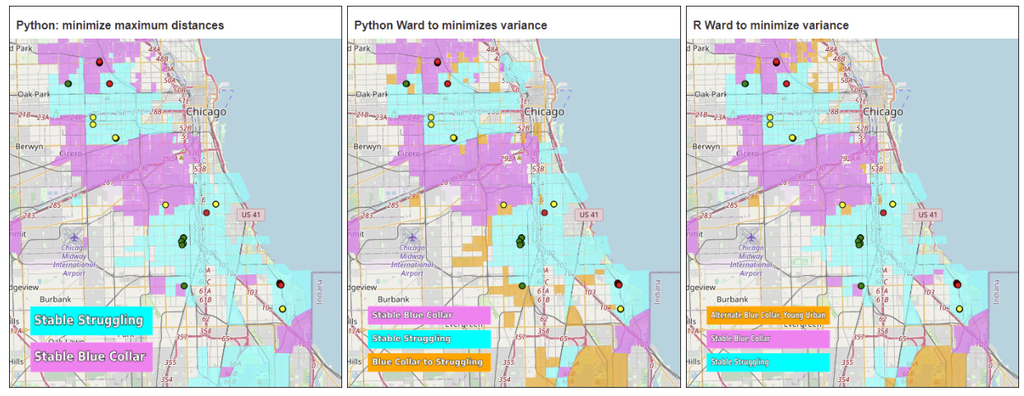

```python
from mpl_toolkits.axes_grid1 import ImageGrid
import matplotlib.image as mpimg

img_list=[]
for f in os.listdir(htmldir):
    if ('seqclust' in f) and ('.png' in f):
        img_list.append(mpimg.imread(os.path.join(htmldir, f)))

fig = plt.figure(figsize=(22., 33.))
grid = ImageGrid(fig, 111,  # similar to subplot(111)
                 nrows_ncols=(1, 3),  # creates 2x3 grid of axes
                 axes_pad=0.1,  # pad between axes in inch.
                 share_all=True)
grid[0].get_yaxis().set_ticks([])
grid[0].get_xaxis().set_ticks([])

for ax, im in zip(grid, img_list):
    # Iterating over the grid returns the Axes.
    ax.imshow(im)

plt.show()
```